# Module 4 Lab - Visualization

**Fix**: Break each quantile out to a chart with different chart color for each quantile

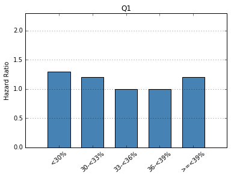

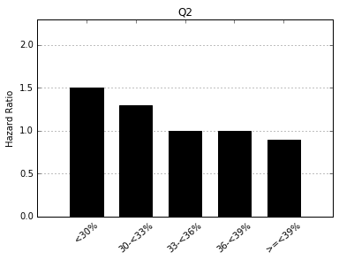

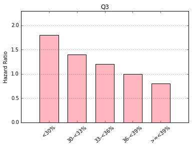

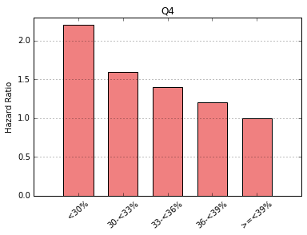

```python
q1_data = [1.3,1.2,1.0,1.0,1.2]
q2_data = [1.5,1.3,1.0,1.0,0.9]
q3_data = [1.8,1.4,1.2,1.0,0.8]
q4_data = [2.2,1.6,1.4,1.2,1.0]

width = 1/1.5

figure, axes = plt.subplots()
x = range( len( q1_data))
axes.bar(x, q1_data, width, color="steelblue", align="center")
axes.set_xticks([0, 1, 2, 3, 4])
axes.set_xticklabels(["<30%", "30-<33%", "33-<36%", "36-<39%", ">=<39%"], rotation=40)
axes.set_ylabel("Hazard Ratio")
axes.yaxis.grid( b=True, which="major")
axes.set_ylim((0, 2.3))
plt.title("Q1")
plt.show()

figure, axes = plt.subplots()
x = range( len( q2_data))
axes.bar(x, q2_data, width, color="black", align="center")
axes.set_xticks([0, 1, 2, 3, 4])
axes.set_xticklabels(["<30%", "30-<33%", "33-<36%", "36-<39%", ">=<39%"], rotation=40)
axes.set_ylabel("Hazard Ratio")
axes.yaxis.grid( b=True, which="major")
axes.set_ylim((0, 2.3))
plt.title("Q2")
plt.show()

figure, axes = plt.subplots()
x = range( len( q3_data))
axes.bar(x, q3_data, width, color="lightpink", align="center")
axes.set_xticks([0, 1, 2, 3, 4])
axes.set_xticklabels(["<30%", "30-<33%", "33-<36%", "36-<39%", ">=<39%"], rotation=40)
axes.set_ylabel("Hazard Ratio")
axes.yaxis.grid( b=True, which="major")
axes.set_ylim((0, 2.3))
plt.title("Q3")
plt.show()

figure, axes = plt.subplots()
x = range( len( q4_data))
axes.bar(x, q4_data, width, color="lightcoral", align="center")
axes.set_xticks([0, 1, 2, 3, 4])
axes.set_xticklabels(["<30%", "30-<33%", "33-<36%", "36-<39%", ">=<39%"], rotation=40)
axes.set_ylabel("Hazard Ratio")
axes.yaxis.grid( b=True, which="major")
axes.set_ylim((0, 2.3))
plt.title("Q4")
plt.show()
```

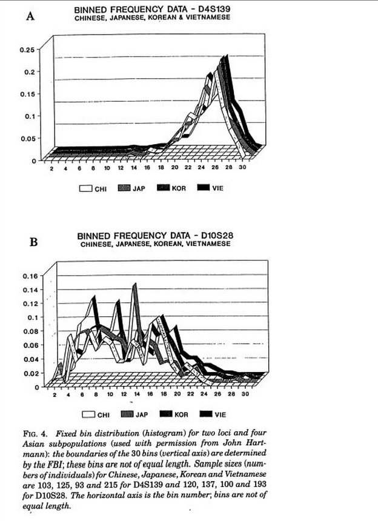

```python
Image( "resources/chart_17.jpg", width=500)
```

**What's wrong:**  
-Color choice makes it difficult to tell the difference between each line  
-3-d chart makes it hard to get values  
-x-axis (bins) aren't equal length  
-appears to use a line chart to describe non-temporal data  
-Context is extremely hard to decipher, what does "frequency bin" mean?  
-Broken law of small multiples

**Fix:** break each chart out into its own histogram, if possible create bins of equal size, only Chinese is shown below because extracting data from the chart was too painful.

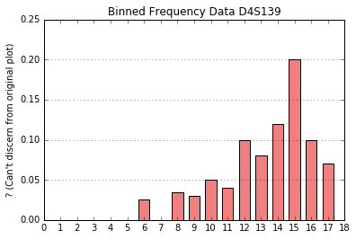

```python
chinese_data = [0,0,0,0,0,0,0.025,0,0.035,0.030,0.05,0.04,0.1,0.08,0.12,0.2,0.1,0.07,0]
figure, axes = plt.subplots()
width = 1/1.5
x = range( len( chinese_data))
axes.bar(x, chinese_data, width, color="lightcoral", align="center")
axes.set_xticks([i for i in xrange(len(chinese_data))])
axes.set_ylabel("? (Can't discern from original plot)")
axes.yaxis.grid( b=True, which="major")
axes.set_ylim((0, 0.25))
axes.set_xlim((0,18))
plt.title("Binned Frequency Data D4S139")
plt.show()
```

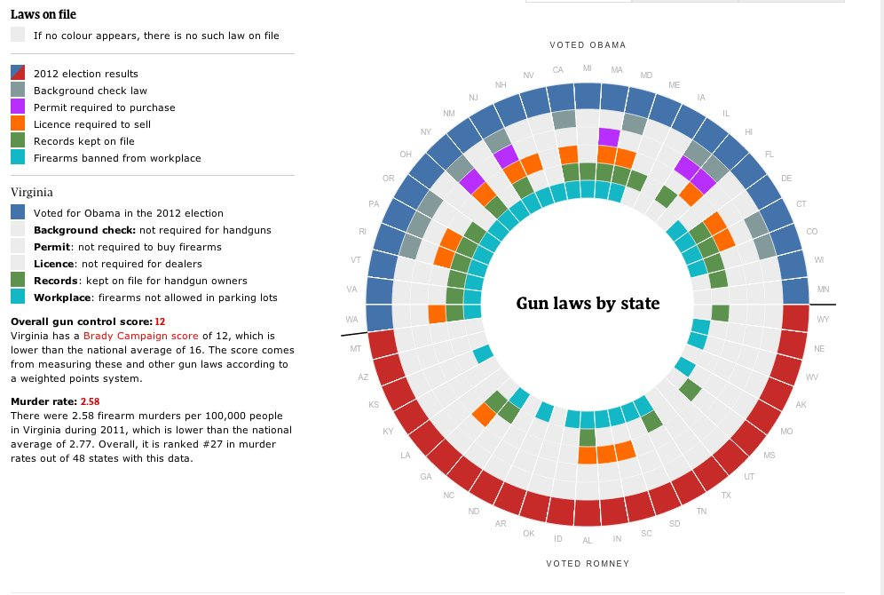

```python
Image( "resources/chart_18.jpg", width=500)
```

**What's wrong:**  
-Data doesn't really belong in a chart as most of it is boolean (did a certain state vote for or against a certain gun law), this "chart" is more like a infographic  
-Colors aren't color blind safe and uses two very similar shades of gray as to different values  
-Depending the news article this appeared in, knowing if a state voted for Obama or Romney doesn't add to the message (since it also displays if the state voted as Republican or Democratic)  
-I don't have the domain knowledge to know for sure but the infographic boils gun laws down to only 5 pieces of legislation, indicates maybe oversimplification is in play

**Fix:** Simple table since this is all categorical information

| State | Workplace | Records | Licence | Permit | Background Check | Voted |
| --- | --- | --- | --- | --- | --- | --- |
| Ohio | Yes | No | No | No | No | Democratic |
| Maryland | Yes | Yes | Yes | No | Yes | Democratic |
| ... | ... | ... | ... | ... | ... | ... |

Not all errors are so egregious. (These are all taken from the "worst charts ever" except Chart 13). There are two charts on the blog post, what is wrong with them?

[App Virality: Trello vs Asana](https://www.process.st/app-virality-trello-vs-asana/?utm_campaign=Submission&utm_medium=Community&utm_source=GrowthHackers.com)

**What's wrong:**  
-Uses pie chart, poor choice because wedges change in two dimensions as the reader's eye leaves the center of the pie chart  
-Pie chart uses highly saturated colors  
-Pie chart has a very unclear message and can be interpreted to mean multiple ideas (originally brought up by Christopher in my group discussion)  
-In relation to the pie chart, the bar chart doesn't seem to mean anything. Most ways of reading the bar chart contradict the values in the pie chart